# Binomial Mixture and Alternate Binomial Distributions PMF values

## Probability Mass Function values for Correlated Binomial Distribution

Pmf values of Correlated Binomial distribution are influenced by covariance value cov and probability value p. They provide very nuance Pmf values when cov and p changes. Below given plot explains the situation of how Pmf values change with regarding to cov and p.

- p is the probability value in between zero and one.
- cov is the covariance value in between negative infinity and positive infinity.

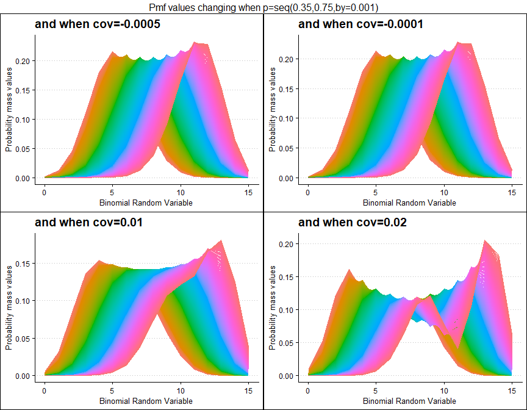

```r
cov.0001 <- dCorrBinplot(p=seq(0.35,0.75,by=0.001),cov=-0.0005,
                       plot_title="and when cov=-0.0005",p_seq= T)
cov.0005 <- dCorrBinplot(p=seq(0.35,0.75,by=0.001),cov=-0.0001,
                       plot_title="and when cov=-0.0001",p_seq= T)
 cov0.01 <- dCorrBinplot(p=seq(0.35,0.75,by=0.001),cov=0.01,
                        plot_title="and when cov=0.01",p_seq= T)
 cov0.05 <- dCorrBinplot(p=seq(0.35,0.75,by=0.001),cov=0.02,
                        plot_title="and when cov=0.02",p_seq= T)

grid.arrange(cov.0001,cov.0005,cov0.01,cov0.05,nrow=2,
             top="Pmf values changing when p=seq(0.35,0.75,by=0.001)")
```

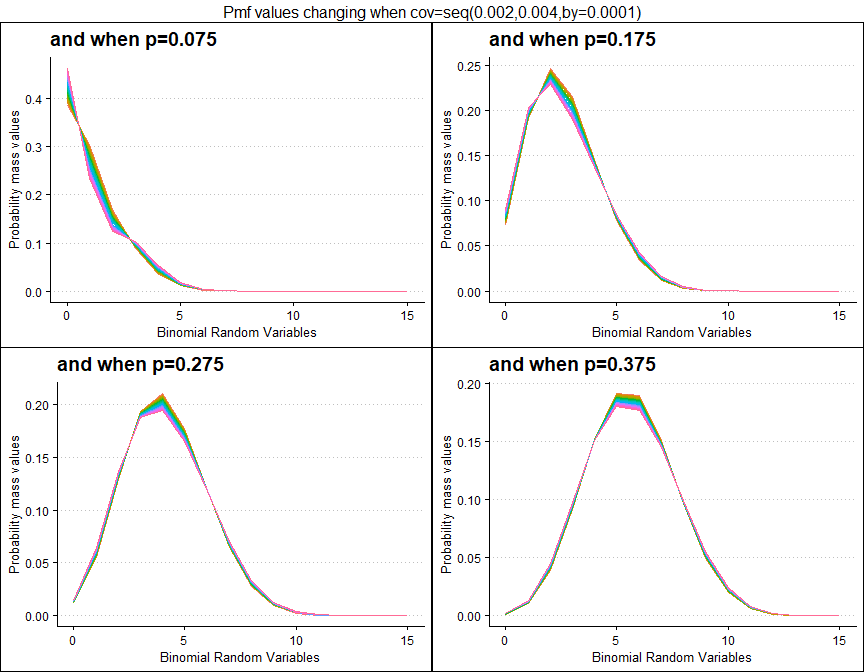

```r
p0.075 <- dCorrBinplot(cov=seq(0.002,0.004,by=.0001),p=0.075,
                    plot_title="and when p=0.075",p_seq= F)
p0.175 <- dCorrBinplot(cov=seq(0.002,0.004,by=.0001),p=0.175,
                    plot_title="and when p=0.175",p_seq= F)
p0.275 <- dCorrBinplot(cov=seq(0.002,0.004,by=.0001),p=0.275,
                    plot_title="and when p=0.275",p_seq= F)
p0.375 <- dCorrBinplot(cov=seq(0.002,0.004,by=.0001),p=0.375,
                    plot_title="and when p=0.375",p_seq= F)

grid.arrange(p0.075,p0.175,p0.275,p0.375,nrow=2,
             top="Pmf values changing when cov=seq(0.002,0.004,by=0.0001)")
```

## Probability Mass Function values for Multiplicative Binomial Distribution

Similar to COM Poisson Binomial and Correlated Binomial distributions this distribution is also influenced by the probability value. Although most influence can happen through the theta parameter as well. Therefore by changing values of theta parameter and p value we can clearly see how Pmf values change. Given below are the plots for that.

- p is the probability value in between zero and one.
- theta parameter is in the domain region of above zero.

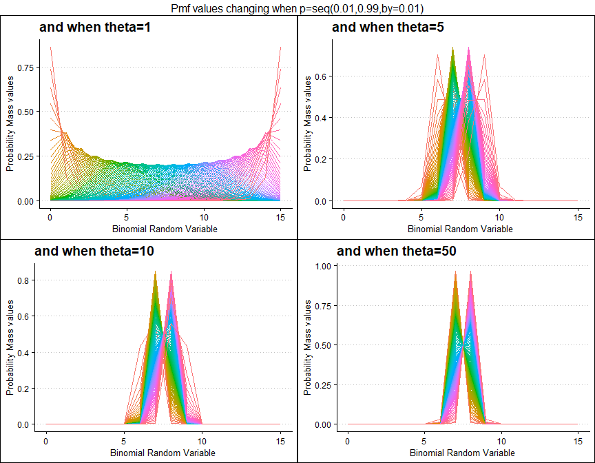

```r
 theta1 <- dMultiBinplot(p=seq(0.01,0.99,by=0.01),theta=1,
                       plot_title="and when theta=1",p_seq= T)
 theta5 <- dMultiBinplot(p=seq(0.01,0.99,by=0.01),theta=5,
                       plot_title="and when theta=5",p_seq= T)
theta10 <- dMultiBinplot(p=seq(0.01,0.99,by=0.01),theta=10,
                      plot_title="and when theta=10",p_seq= T)
theta50 <- dMultiBinplot(p=seq(0.01,0.99,by=0.01),theta=50,
                      plot_title="and when theta=50",p_seq= T)

grid.arrange(theta1,theta5,theta10,theta50,nrow=2,
             top="Pmf values changing when p=seq(0.01,0.99,by=0.01)")
```

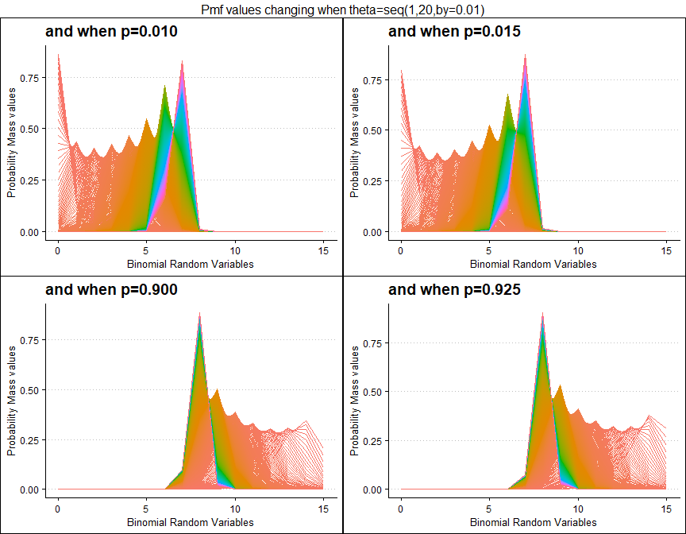

```r
p0.10 <- dMultiBinplot(theta=seq(1,20,by=0.01),p=0.01,
                     plot_title="and when p=0.010",p_seq= F)
p0.25 <- dMultiBinplot(theta=seq(1,20,by=0.01),p=0.015,
                     plot_title="and when p=0.015",p_seq= F)
p0.50 <- dMultiBinplot(theta=seq(1,20,by=0.01),p=0.90,
                     plot_title="and when p=0.900",p_seq= F)
p0.75 <- dMultiBinplot(theta=seq(1,20,by=0.01),p=0.925,
                     plot_title="and when p=0.925",p_seq= F)

grid.arrange(p0.10,p0.25,p0.50,p0.75,nrow=2,
             top="Pmf values changing when theta=seq(1,20,by=0.01)")
```

## Probability Mass Function values for Lovinson Multiplicative Binomial Distribution

Similar to Multiplicative Binomial distribution. By changing values of phi parameter and p value we can clearly see how Pmf values change. Given below are the plots for that.

- p is the probability value in between zero and one.
- phi parameter is in the domain region of above zero.

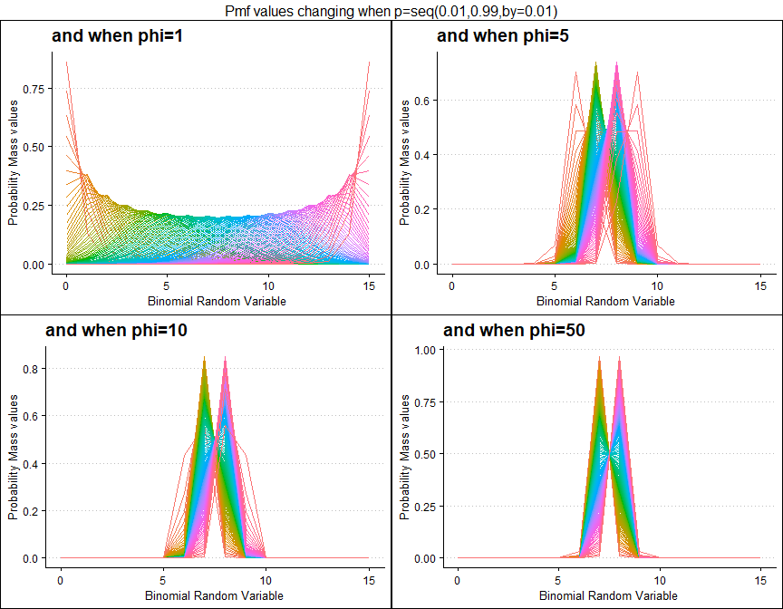

```r
 phi1 <- dLMBinplot(p=seq(0.01,0.99,by=0.01),phi=1,
                      plot_title="and when phi=1",p_seq= T)
 phi5 <- dLMBinplot(p=seq(0.01,0.99,by=0.01),phi=5,
                      plot_title="and when phi=5",p_seq= T)
phi10 <- dLMBinplot(p=seq(0.01,0.99,by=0.01),phi=10,
                       plot_title="and when phi=10",p_seq= T)
phi50 <- dLMBinplot(p=seq(0.01,0.99,by=0.01),phi=50,
                       plot_title="and when phi=50",p_seq= T)

grid.arrange(phi1,phi5,phi10,phi50,nrow=2,
             top="Pmf values changing when p=seq(0.01,0.99,by=0.01)")
```

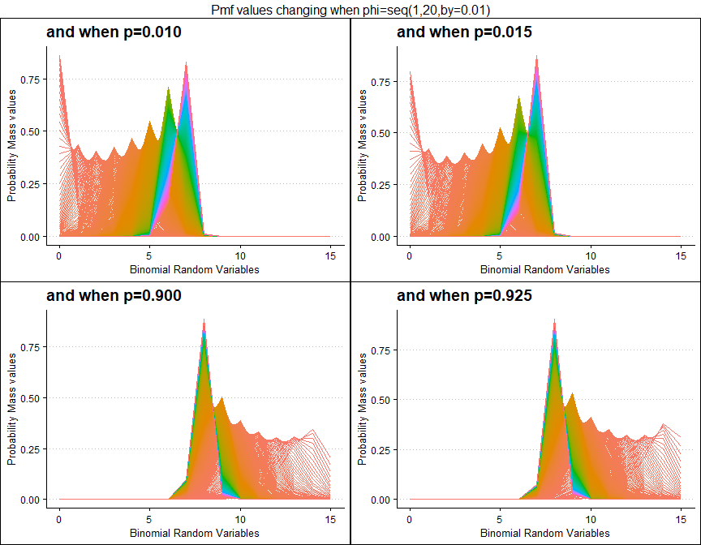

```r
p0.10 <- dLMBinplot(phi=seq(1,20,by=0.01),p=0.01,
                     plot_title="and when p=0.010",p_seq= F)
p0.25 <- dLMBinplot(phi=seq(1,20,by=0.01),p=0.015,
                     plot_title="and when p=0.015",p_seq= F)
p0.50 <- dLMBinplot(phi=seq(1,20,by=0.01),p=0.90,
                     plot_title="and when p=0.900",p_seq= F)
p0.75 <- dLMBinplot(phi=seq(1,20,by=0.01),p=0.925,
                     plot_title="and when p=0.925",p_seq= F)

grid.arrange(p0.10,p0.25,p0.50,p0.75,nrow=2,
             top="Pmf values changing when phi=seq(1,20,by=0.01)")
```